# Breast Cancer analysis

### BY: Harish Osthe

#### let's import the required libraries

```python
import pandas as pd
import numpy as np
import matplotlib.pyplot as plt
import seaborn as sns
import cufflinks as cf
import plotly as py
from plotly.offline import init_notebook_mode,plot,iplot
```

```python
init_notebook_mode(connected=True)
cf.go_offline()
```

#### loading breast cancer dataset from sklearn

```python
from sklearn.datasets import load_breast_cancer
```

```python
b_cancer=load_breast_cancer()
```

```python
# b_cancer
```

#### There are two target values malignant (0) and benign (1)

```python
b_cancer.target_names
```

```
array(['malignant', 'benign'], dtype='<U9')
```

#### We have 30 features in our dataset

```python
b_cancer["feature_names"]
```

```
array(['mean radius', 'mean texture', 'mean perimeter', 'mean area',
       'mean smoothness', 'mean compactness', 'mean concavity',
       'mean concave points', 'mean symmetry', 'mean fractal dimension',
       'radius error', 'texture error', 'perimeter error', 'area error',
       'smoothness error', 'compactness error', 'concavity error',
       'concave points error', 'symmetry error',
       'fractal dimension error', 'worst radius', 'worst texture',
       'worst perimeter', 'worst area', 'worst smoothness',
       'worst compactness', 'worst concavity', 'worst concave points',
       'worst symmetry', 'worst fractal dimension'], dtype='<U23')
```

#### Let's convert the sklean's dictionary to pandas to make it faster analysis

```python
df_cancer=pd.DataFrame(np.c_[b_cancer["data"],b_cancer["target"]],columns=np.append(b_cancer["feature_names"],["target"]))
```

```python
df_cancer.head()
```

|  | mean radius | mean texture | mean perimeter | mean area | mean smoothness | mean compactness | mean concavity | mean concave points | mean symmetry | mean fractal dimension | ... | worst texture | worst perimeter | worst area | worst smoothness | worst compactness | worst concavity | worst concave points | worst symmetry | worst fractal dimension | target |
| --- | --- | --- | --- | --- | --- | --- | --- | --- | --- | --- | --- | --- | --- | --- | --- | --- | --- | --- | --- | --- | --- |
| 0 | 17.99 | 10.38 | 122.80 | 1001.0 | 0.11840 | 0.27760 | 0.3001 | 0.14710 | 0.2419 | 0.07871 | ... | 17.33 | 184.60 | 2019.0 | 0.1622 | 0.6656 | 0.7119 | 0.2654 | 0.4601 | 0.11890 | 0.0 |
| 1 | 20.57 | 17.77 | 132.90 | 1326.0 | 0.08474 | 0.07864 | 0.0869 | 0.07017 | 0.1812 | 0.05667 | ... | 23.41 | 158.80 | 1956.0 | 0.1238 | 0.1866 | 0.2416 | 0.1860 | 0.2750 | 0.08902 | 0.0 |
| 2 | 19.69 | 21.25 | 130.00 | 1203.0 | 0.10960 | 0.15990 | 0.1974 | 0.12790 | 0.2069 | 0.05999 | ... | 25.53 | 152.50 | 1709.0 | 0.1444 | 0.4245 | 0.4504 | 0.2430 | 0.3613 | 0.08758 | 0.0 |
| 3 | 11.42 | 20.38 | 77.58 | 386.1 | 0.14250 | 0.28390 | 0.2414 | 0.10520 | 0.2597 | 0.09744 | ... | 26.50 | 98.87 | 567.7 | 0.2098 | 0.8663 | 0.6869 | 0.2575 | 0.6638 | 0.17300 | 0.0 |
| 4 | 20.29 | 14.34 | 135.10 | 1297.0 | 0.10030 | 0.13280 | 0.1980 | 0.10430 | 0.1809 | 0.05883 | ... | 16.67 | 152.20 | 1575.0 | 0.1374 | 0.2050 | 0.4000 | 0.1625 | 0.2364 | 0.07678 | 0.0 |

5 rows × 31 columns

#### Let's see how many malignant & benign tumors are there in our dataset.

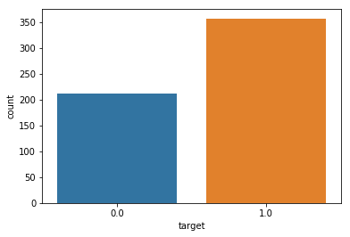

```python
sns.countplot(df_cancer["target"]) # 0=ma 1=bei
```

##### From the above plot we can see that benign is more than malignant...

#### Now lets print a simple correlation graph in our data set

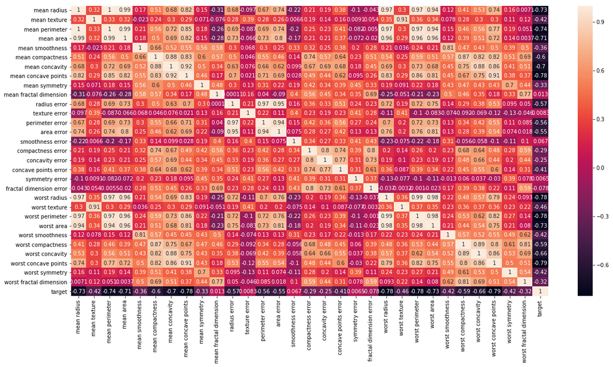

```python
plt.figure(figsize=(20,10))
sns.heatmap(df_cancer.corr(),annot=True)
```

#### Ok now lets get into business... lets divide the targets and features

```python
X=df_cancer.drop(["target"],axis=1) # Features
```

```python
X.head()
```

|  | mean radius | mean texture | mean perimeter | mean area | mean smoothness | mean compactness | mean concavity | mean concave points | mean symmetry | mean fractal dimension | ... | worst radius | worst texture | worst perimeter | worst area | worst smoothness | worst compactness | worst concavity | worst concave points | worst symmetry | worst fractal dimension |
| --- | --- | --- | --- | --- | --- | --- | --- | --- | --- | --- | --- | --- | --- | --- | --- | --- | --- | --- | --- | --- | --- |
| 0 | 17.99 | 10.38 | 122.80 | 1001.0 | 0.11840 | 0.27760 | 0.3001 | 0.14710 | 0.2419 | 0.07871 | ... | 25.38 | 17.33 | 184.60 | 2019.0 | 0.1622 | 0.6656 | 0.7119 | 0.2654 | 0.4601 | 0.11890 |
| 1 | 20.57 | 17.77 | 132.90 | 1326.0 | 0.08474 | 0.07864 | 0.0869 | 0.07017 | 0.1812 | 0.05667 | ... | 24.99 | 23.41 | 158.80 | 1956.0 | 0.1238 | 0.1866 | 0.2416 | 0.1860 | 0.2750 | 0.08902 |
| 2 | 19.69 | 21.25 | 130.00 | 1203.0 | 0.10960 | 0.15990 | 0.1974 | 0.12790 | 0.2069 | 0.05999 | ... | 23.57 | 25.53 | 152.50 | 1709.0 | 0.1444 | 0.4245 | 0.4504 | 0.2430 | 0.3613 | 0.08758 |
| 3 | 11.42 | 20.38 | 77.58 | 386.1 | 0.14250 | 0.28390 | 0.2414 | 0.10520 | 0.2597 | 0.09744 | ... | 14.91 | 26.50 | 98.87 | 567.7 | 0.2098 | 0.8663 | 0.6869 | 0.2575 | 0.6638 | 0.17300 |
| 4 | 20.29 | 14.34 | 135.10 | 1297.0 | 0.10030 | 0.13280 | 0.1980 | 0.10430 | 0.1809 | 0.05883 | ... | 22.54 | 16.67 | 152.20 | 1575.0 | 0.1374 | 0.2050 | 0.4000 | 0.1625 | 0.2364 | 0.07678 |

5 rows × 30 columns

```python
y=df_cancer["target"] #Targets
```

```python
y.head()
```

```
0    0.0
1    0.0
2    0.0
3    0.0
4    0.0
Name: target, dtype: float64
```

#### Lets split the data into training and testing set....

```python
from sklearn.model_selection import train_test_split
```

```python
X_train, X_test, y_train, y_test = train_test_split(X, y, test_size=0.3, random_state=8)
```

#### Time for our machine learning model....

```python
from sklearn.svm import SVC
```

```python
from sklearn.metrics import classification_report, confusion_matrix
```

```python
cancer_model=SVC()
```

```python
cancer_model.fit(X_train,y_train)
```

```
SVC(C=1.0, cache_size=200, class_weight=None, coef0=0.0,
  decision_function_shape='ovr', degree=3, gamma='auto_deprecated',
  kernel='rbf', max_iter=-1, probability=False, random_state=None,
  shrinking=True, tol=0.001, verbose=False)
```

```python
predict=cancer_model.predict(X_test)
```

```python
predict
```

```
array([1., 1., 1., 1., 1., 1., 1., 1., 1., 1., 1., 1., 1., 1., 1., 1., 1.,
       1., 1., 1., 1., 1., 1., 1., 1., 1., 1., 1., 1., 1., 1., 1., 1., 1.,
       1., 1., 1., 1., 1., 1., 1., 1., 1., 1., 1., 1., 1., 1., 1., 1., 1.,
       1., 1., 1., 1., 1., 1., 1., 1., 1., 1., 1., 1., 1., 1., 1., 1., 1.,
       1., 1., 1., 1., 1., 1., 1., 1., 1., 1., 1., 1., 1., 1., 1., 1., 1.,
       1., 1., 1., 1., 1., 1., 1., 1., 1., 1., 1., 1., 1., 1., 1., 1., 1.,
       1., 1., 1., 1., 1., 1., 1., 1., 1., 1., 1., 1., 1., 1., 1., 1., 1.,
       1., 1., 1., 1., 1., 1., 1., 1., 1., 1., 1., 1., 1., 1., 1., 1., 1.,
       1., 1., 1., 1., 1., 1., 1., 1., 1., 1., 1., 1., 1., 1., 1., 1., 1.,
       1., 1., 1., 1., 1., 1., 1., 1., 1., 1., 1., 1., 1., 1., 1., 1., 1.,
       1.])
```

```python
cm=confusion_matrix(y_test,predict)
```

```
array([[  0,  66],
       [  0, 105]], dtype=int64)
```

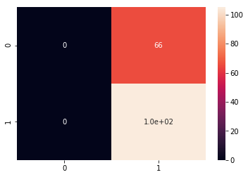

```python
sns.heatmap(cm,annot=True)
cm
```

##### OOOO what happned !...

```python
print(classification_report(y_test,predict))
```

```
              precision    recall  f1-score   support

         0.0       0.00      0.00      0.00        66
         1.0       0.61      1.00      0.76       105

   micro avg       0.61      0.61      0.61       171
   macro avg       0.31      0.50      0.38       171
weighted avg       0.38      0.61      0.47       171
```

##### I forgot to normalize the data as u can see that our features are in different scales, ex: mean radius are in 10s and mean areas are in 1000s and 100s, this results in curse of dimensionality... so lets normalize our data.

```python
min_test=X_test.min()
range_test=(X_test - min_test).max()

X_test_scaled=(X_test - min_test)/range_test
```

```python
min_train=X_train.min()
range_train=(X_train - min_train).max()

X_train_scaled=(X_train - min_train)/range_train
```

```python
normalized_model=SVC()
```

```python
normalized_model.fit(X_train_scaled,y_train)
```

```
SVC(C=1.0, cache_size=200, class_weight=None, coef0=0.0,
  decision_function_shape='ovr', degree=3, gamma='auto_deprecated',
  kernel='rbf', max_iter=-1, probability=False, random_state=None,
  shrinking=True, tol=0.001, verbose=False)
```

```python
normalized_model_predit=normalized_model.predict(X_test_scaled)
```

```python
cm1=confusion_matrix(y_test,normalized_model_predit)
```

```
array([[ 58,   8],
       [  0, 105]], dtype=int64)
```

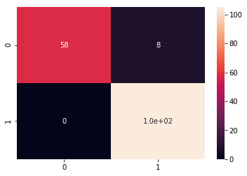

```python
sns.heatmap(cm1,annot=True)
cm1
```

```python
print(classification_report(y_test,normalized_model_predit))
```

```
              precision    recall  f1-score   support

         0.0       1.00      0.88      0.94        66
         1.0       0.93      1.00      0.96       105

   micro avg       0.95      0.95      0.95       171
   macro avg       0.96      0.94      0.95       171
weighted avg       0.96      0.95      0.95       171
```

##### ooo... did u see that by just simply normalizing our data we have a better model now... now will try to improve our model more by using GridSearchCV for tuning hyperparameter in our SVC model

```python
par={"C":[0.1,1,5,10,100],"gamma":[1,0.1,0.01,0.001],"kernel":["rbf"]}
```

```python
from sklearn.model_selection import GridSearchCV
```

```python
grid=GridSearchCV(SVC(),par,refit=True,verbose=4)
```

```python
grid.fit(X_train_scaled,y_train)
```

[output not shown]

[output cut: 66 more lines]

[output not shown]

```
[Parallel(n_jobs=1)]: Done  60 out of  60 | elapsed:    0.5s finished
```

```
GridSearchCV(cv='warn', error_score='raise-deprecating',
       estimator=SVC(C=1.0, cache_size=200, class_weight=None, coef0=0.0,
  decision_function_shape='ovr', degree=3, gamma='auto_deprecated',
  kernel='rbf', max_iter=-1, probability=False, random_state=None,
  shrinking=True, tol=0.001, verbose=False),
       fit_params=None, iid='warn', n_jobs=None,
       param_grid={'C': [0.1, 1, 5, 10, 100], 'gamma': [1, 0.1, 0.01, 0.001], 'kernel': ['rbf']},
       pre_dispatch='2*n_jobs', refit=True, return_train_score='warn',
       scoring=None, verbose=4)
```

```python
grid.best_params_
```

```
{'C': 1, 'gamma': 1, 'kernel': 'rbf'}
```

```python
gridcv_predict=grid.predict(X_test_scaled)
```

```python
cm2=confusion_matrix(y_test,gridcv_predict)
```

```
array([[ 64,   2],
       [  0, 105]], dtype=int64)
```

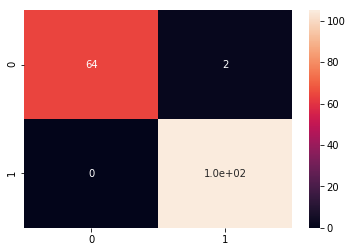

```python
sns.heatmap(cm2,annot=True)
cm2
```

```python
print(classification_report(y_test,gridcv_predict))
```

```
              precision    recall  f1-score   support

         0.0       1.00      0.97      0.98        66
         1.0       0.98      1.00      0.99       105

   micro avg       0.99      0.99      0.99       171
   macro avg       0.99      0.98      0.99       171
weighted avg       0.99      0.99      0.99       171
```

##### oh,.... check this i got 99% accurate now this is a better model.. for my breast cancer prediction.......